# W271 - Assignment 1

Chandra Shekar Bikkanur

```r
#Loading some libraries for this assignment
library(car)
library(dplyr)
library(Hmisc)
library(ggplot2)
```

**Question 1.1:** Use the code from the week 1 live session file and: (1) redo the exercise for `n=50, n=100, n=500`, (2) plot the graphs, and (3) describe what you have observed from the results. Use the same `pi.seq` as in the live session code.

- **1.1.1:**

```r
# function to get the wald true coverage
wald.CI.true.coverage = function(pi, alpha=0.05, n) {
  w = 0:n
  pi.hat = w/n
  pmf = dbinom(x=w, size=n, prob=pi)
  var.wald = pi.hat*(1-pi.hat)/n
  wald.CI_lower.bound = pi.hat - qnorm(p = 1-alpha/2)*sqrt(var.wald)
  wald.CI_upper.bound = pi.hat + qnorm(p = 1-alpha/2)*sqrt(var.wald)
  covered.pi = ifelse(test = pi>wald.CI_lower.bound, yes = ifelse(test = pi<wald.CI_upper.bound, yes=1, no=0), no=0)
  wald.CI.true.coverage = sum(covered.pi*pmf)
  wald.df = data.frame(w, pi.hat, round(data.frame(pmf, wald.CI_lower.bound,wald.CI_upper.bound),4), covered.pi)
  return(wald.df)
}

# function to get the wald true coverage matrix for different pi values
get.wald.CI.true.matrix = function(pi, alpha=0.05, n) {
   wald.df = wald.CI.true.coverage(pi=pi, alpha=0.05, n=n)
   wald.CI.true.coverage.level = sum(wald.df$covered.pi*wald.df$pmf)
   pi.seq = seq(0.01,0.99, by=0.01)
   wald.CI.true.matrix = matrix(data=NA,nrow=length(pi.seq),ncol=2)
   counter=1
   for (pi in pi.seq) {
        wald.df2 = wald.CI.true.coverage(pi=pi, alpha=0.05, n=n)
        wald.CI.true.matrix[counter,] = c(pi,sum(wald.df2$covered.pi*wald.df2$pmf))
        counter = counter+1
       }
   return(wald.CI.true.matrix)
}
wald.CI.true.matrix_10   = get.wald.CI.true.matrix(pi = 0.6, alpha=0.05, n=10)
wald.CI.true.matrix_50   = get.wald.CI.true.matrix(pi = 0.6, alpha=0.05, n=50)
wald.CI.true.matrix_100  = get.wald.CI.true.matrix(pi = 0.6, alpha=0.05, n=100)
wald.CI.true.matrix_500  = get.wald.CI.true.matrix(pi = 0.6, alpha=0.05, n=500)
```

- **1.1.2:**

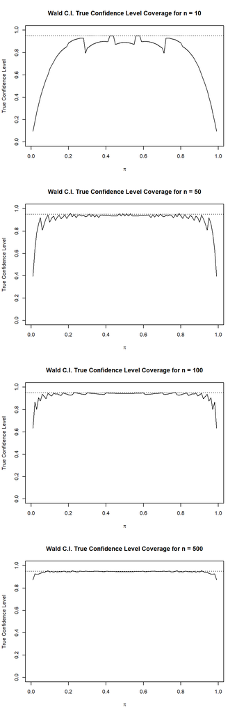

```r
# Plot the true coverage level (for given n and alpha)
alpha=0.05
par(mfrow=c(4,1))
# n=10
plot(x=wald.CI.true.matrix_10[,1],
     y=wald.CI.true.matrix_10[,2],
     ylim=c(0,1),
     main = "Wald C.I. True Confidence Level Coverage for n = 10", xlab=expression(pi),
     ylab="True Confidence Level",
     type="l")
abline(h=1-alpha, lty="dotted")
# n=50
plot(x=wald.CI.true.matrix_50[,1],
     y=wald.CI.true.matrix_50[,2],
     ylim=c(0,1),
     main = "Wald C.I. True Confidence Level Coverage for n = 50", xlab=expression(pi),
     ylab="True Confidence Level",
     type="l")
abline(h=1-alpha, lty="dotted")
# n=100
plot(x=wald.CI.true.matrix_100[,1],
     y=wald.CI.true.matrix_100[,2],
     ylim=c(0,1),
     main = "Wald C.I. True Confidence Level Coverage for n = 100", xlab=expression(pi),
     ylab="True Confidence Level",
     type="l")
abline(h=1-alpha, lty="dotted")
# n=500
plot(x=wald.CI.true.matrix_500[,1],
     y=wald.CI.true.matrix_500[,2],
     ylim=c(0,1),
     main = "Wald C.I. True Confidence Level Coverage for n = 500", xlab=expression(pi),
     ylab="True Confidence Level",
     type="l")
abline(h=1-alpha, lty="dotted")
```

- **1.1.3:** From above 4 plots, we can see that the confidence level coverage is increasing(less fluctuating) as the number of samples increases from 10, 50, 100 to 500.

**Question 1.2:** (1) Modify the code for the Wilson Interval. (2) Do the exercise for `n=10, n=50, n=100, n=500`. (3) Plot the graphs. (4) Describe what you have observed from the results and compare the Wald and Wilson intervals based on your results. Use the same `pi.seq` as in the live session code.

Wilson Confidence Interval for an estimated parameter $\tilde{\pi}$ is as follows

$$\tilde{\pi} \pm \frac{Z_{1-\frac{\alpha}{2}} n^{1/2}}{n + Z^2_{1-\frac{\alpha}{2}}} \sqrt{\hat{\pi}(1-\hat{\pi}) + \frac{Z^2_{1-\frac{\alpha}{2}}}{4n}}$$

where $\tilde{\pi}$ is defined as

$$\tilde{\pi} = \frac{w + \frac{1}{2}Z^2_{1-\frac{\alpha}{2}}}{n + Z^2_{1-\frac{\alpha}{2}}}$$

- **1.2.1:**

```r
# function to get the wilson true coverage
wilson.CI.true.coverage = function(pi, alpha=0.05, n) {
  w = 0:n
  Z = qnorm(p = 1-alpha/2)
  Z2 = Z^2
  pi.hat = (w+(Z2/2))/(n+Z2)
  pmf = dbinom(x=w, size=n, prob=pi)
  delta = (Z*sqrt(n))*sqrt((pi.hat * (1 - pi.hat)) + (Z2)/(4*n))/(n+Z2)
  wilson.CI_lower.bound = pi.hat - delta
  wilson.CI_upper.bound = pi.hat + delta
  covered.pi = ifelse(test = pi>wilson.CI_lower.bound, yes = ifelse(test = pi<wilson.CI_upper.bound, yes=1, no=0), no=0)
  wilson.CI.true.coverage = sum(covered.pi*pmf)
  wilson.df = data.frame(w, pi.hat, round(data.frame(pmf, wilson.CI_lower.bound,wilson.CI_upper.bound),4), covered.pi)
  return(wilson.df)
}
```

- **1.2.2:**

```r
# function to get the wilson true coverage matrix for different pi values
get.wilson.CI.true.matrix = function(pi, alpha=0.05, n) {
   wilson.df = wilson.CI.true.coverage(pi=pi, alpha=0.05, n=n)
   wilson.CI.true.coverage.level = sum(wilson.df$covered.pi*wilson.df$pmf)
   pi.seq = seq(0.01,0.99, by=0.01)
   wilson.CI.true.matrix = matrix(data=NA,nrow=length(pi.seq),ncol=2)
   counter=1
   for (pi in pi.seq) {
        wilson.df2 = wilson.CI.true.coverage(pi=pi, alpha=0.05, n=n)
        wilson.CI.true.matrix[counter,] = c(pi,sum(wilson.df2$covered.pi*wilson.df2$pmf))
        counter = counter+1
       }
   return(wilson.CI.true.matrix)
}
wilson.CI.true.matrix_10   = get.wilson.CI.true.matrix(pi = 0.6, alpha=0.05, n=10)
wilson.CI.true.matrix_50   = get.wilson.CI.true.matrix(pi = 0.6, alpha=0.05, n=50)
wilson.CI.true.matrix_100   = get.wilson.CI.true.matrix(pi = 0.6, alpha=0.05, n=100)
wilson.CI.true.matrix_500   = get.wilson.CI.true.matrix(pi = 0.6, alpha=0.05, n=500)
```

- **1.2.3:**

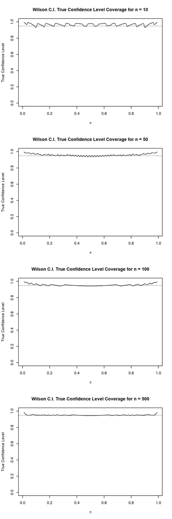

```r
# Plot the true coverage level (for given n and alpha)
par(mfrow=c(4,1))
# n=10
plot(x=wilson.CI.true.matrix_10[,1],
     y=wilson.CI.true.matrix_10[,2],
     ylim=c(0,1),
     main = "Wilson C.I. True Confidence Level Coverage for n = 10", xlab=expression(pi),
     ylab="True Confidence Level",
     type="l")
abline(h=1-alpha, lty="dotted")
# n=50
plot(x=wilson.CI.true.matrix_50[,1],
     y=wilson.CI.true.matrix_50[,2],
     ylim=c(0,1),
     main = "Wilson C.I. True Confidence Level Coverage for n = 50", xlab=expression(pi),
     ylab="True Confidence Level",
     type="l")
abline(h=1-alpha, lty="dotted")
# n=100
plot(x=wilson.CI.true.matrix_100[,1],
     y=wilson.CI.true.matrix_100[,2],
     ylim=c(0,1),
     main = "Wilson C.I. True Confidence Level Coverage for n = 100", xlab=expression(pi),
     ylab="True Confidence Level",
     type="l")
abline(h=1-alpha, lty="dotted")
# n=500
plot(x=wilson.CI.true.matrix_500[,1],
     y=wilson.CI.true.matrix_500[,2],
     ylim=c(0,1),
     main = "Wilson C.I. True Confidence Level Coverage for n = 500", xlab=expression(pi),
     ylab="True Confidence Level",
     type="l")
abline(h=1-alpha, lty="dotted")
```

- **1.2.4:** From the plots for wald confidence coverage and wilson confidence coverage, we can see that the wilson confidence coverage shows the 95% coverage relatively more accurate for less number of samples than wald coverage.

**Question 2:** Using the `placekick.BW.csv` data, `Distance`, `Weather`, `Wind15`, `Temperature`, `Grass`, `Pressure`, and `Ice` as explanatory variables in a logistic regression model, complete the following:

- 1. Estimate the model and properly deﬁne the indicator variables used within it.
- 2. The authors use “Sun” as the base level category for Weather, which is not the default level that R uses. Describe how “Sun” can be speciﬁed as the base level in R.
- 3. Perform LRTs for all explanatory variables to evaluate their importance within the model. Discuss the results.
- 4. Estimate an appropriate odds ratio for distance, and compute the corresponding conﬁdence interval. Interpret the odds ratio.

```r
# Load the data
placekick <- read.csv("placekick.BW.csv", header = TRUE, sep = ",")
head(placekick, 10)
```

```
##      GameNum Kicker Good Distance Weather Wind15 Temperature Grass
## 1  2002-0101 Bryant    Y       29     Sun      0        Nice     1
## 2  2002-0101 Bryant    Y       33     Sun      0        Nice     1
## 3  2002-0101 Cortez    N       25     Sun      0        Nice     1
## 4  2002-0101 Cortez    Y       23     Sun      0        Nice     1
## 5  2002-0101 Cortez    N       48     Sun      0        Nice     1
## 6  2002-0101 Cortez    Y       33     Sun      0        Nice     1
## 7  2002-0101 Cortez    Y       36     Sun      0        Nice     1
## 8  2002-0102   Hall    Y       34     Sun      0         Hot     0
## 9  2002-0102   Hall    Y       45     Sun      0         Hot     0
## 10 2002-0102   Hall    N       48     Sun      0         Hot     0
##    Pressure Ice
## 1         N   0
## 2         N   0
## 3         N   0
## 4         N   0
## 5         N   0
## 6         N   0
## 7         Y   0
## 8         N   0
## 9         N   0
## 10        N   0
```

```r
#check the structure of the data frame
str(placekick)
```

```
## 'data.frame':    2003 obs. of  10 variables:
##  $ GameNum    : Factor w/ 523 levels "2002-0101","2002-0102",..: 1 1 1 1 1 1 1 2 2 2 ...
##  $ Kicker     : Factor w/ 52 levels "Akers","Andersen",..: 8 8 13 13 13 13 13 27 27 27 ...
##  $ Good       : Factor w/ 2 levels "N","Y": 2 2 1 2 1 2 2 2 2 1 ...
##  $ Distance   : int  29 33 25 23 48 33 36 34 45 48 ...
##  $ Weather    : Factor w/ 4 levels "Clouds","Inside",..: 4 4 4 4 4 4 4 4 4 4 ...
##  $ Wind15     : int  0 0 0 0 0 0 0 0 0 0 ...
##  $ Temperature: Factor w/ 3 levels "Cold","Hot","Nice": 3 3 3 3 3 3 3 2 2 2 ...
##  $ Grass      : int  1 1 1 1 1 1 1 0 0 0 ...
##  $ Pressure   : Factor w/ 2 levels "N","Y": 1 1 1 1 1 1 2 1 1 1 ...
##  $ Ice        : int  0 0 0 0 0 0 0 0 0 0 ...
```

- **2.a:**

```r
mod.fit <- glm(Good ~ Distance + Weather + Wind15 + Temperature + Grass + Pressure + Ice, family = binomial(link = logit), data = placekick )
summary(mod.fit)
```

```
##
## Call:
## glm(formula = Good ~ Distance + Weather + Wind15 + Temperature +
##     Grass + Pressure + Ice, family = binomial(link = logit),
##     data = placekick)
##
## Deviance Residuals:
##     Min       1Q   Median       3Q      Max
## -2.6804   0.2599   0.4360   0.7148   1.8698
##
## Coefficients:
##                  Estimate Std. Error z value Pr(>|z|)
## (Intercept)      5.740185   0.369597  15.531   <2e-16 ***
## Distance        -0.109600   0.007188 -15.249   <2e-16 ***
## WeatherInside   -0.083030   0.214711  -0.387   0.6990
## WeatherSnowRain -0.444193   0.217852  -2.039   0.0415 *
## WeatherSun      -0.247582   0.139642  -1.773   0.0762 .
## Wind15          -0.243777   0.175527  -1.389   0.1649
## TemperatureHot   0.250013   0.247540   1.010   0.3125
## TemperatureNice  0.234932   0.181461   1.295   0.1954
## Grass           -0.328435   0.160050  -2.052   0.0402 *
## PressureY        0.270174   0.262809   1.028   0.3039
## Ice             -0.876133   0.451251  -1.942   0.0522 .
## ---
## Signif. codes:  0 '***' 0.001 '**' 0.01 '*' 0.05 '.' 0.1 ' ' 1
##
## (Dispersion parameter for binomial family taken to be 1)
##
##     Null deviance: 2104.0  on 2002  degrees of freedom
## Residual deviance: 1791.3  on 1992  degrees of freedom
## AIC: 1813.3
##
## Number of Fisher Scoring iterations: 5
```

- **2.b:** Let us check the exisitng base level for `Weather` variable

```r
# Check the existing base level for Weather
levels(placekick$Weather)
```

```
## [1] "Clouds"   "Inside"   "SnowRain" "Sun"
```

We see that `Clouds`to be the base level for `Weather` factor variable. Now, we will relevel the dataframe with `Sun` as the base level.

```r
# For Weather variable, relevel the base level to "Sun"
placekick <- within(placekick, Weather <- relevel(Weather, ref = "Sun"))
levels(placekick$Weather)
```

```
## [1] "Sun"      "Clouds"   "Inside"   "SnowRain"
```

We can see from above updated levels, “Sun” became the current base level for `Weather` variable. Now let us re run the above logistic model with this updated base level to see difference in the indicator variables.

```r
mod.fit2 <- glm(Good ~ Distance + Weather + Wind15 + Temperature + Grass + Pressure + Ice, family = binomial(link = logit), data = placekick )
summary(mod.fit2)
```

```
##
## Call:
## glm(formula = Good ~ Distance + Weather + Wind15 + Temperature +
##     Grass + Pressure + Ice, family = binomial(link = logit),
##     data = placekick)
##
## Deviance Residuals:
##     Min       1Q   Median       3Q      Max
## -2.6804   0.2599   0.4360   0.7148   1.8698
##
## Coefficients:
##                  Estimate Std. Error z value Pr(>|z|)
## (Intercept)      5.492602   0.370141  14.839   <2e-16 ***
## Distance        -0.109600   0.007188 -15.249   <2e-16 ***
## WeatherClouds    0.247582   0.139642   1.773   0.0762 .
## WeatherInside    0.164553   0.215062   0.765   0.4442
## WeatherSnowRain -0.196611   0.219015  -0.898   0.3693
## Wind15          -0.243777   0.175527  -1.389   0.1649
## TemperatureHot   0.250013   0.247540   1.010   0.3125
## TemperatureNice  0.234932   0.181461   1.295   0.1954
## Grass           -0.328435   0.160050  -2.052   0.0402 *
## PressureY        0.270174   0.262809   1.028   0.3039
## Ice             -0.876133   0.451251  -1.942   0.0522 .
## ---
## Signif. codes:  0 '***' 0.001 '**' 0.01 '*' 0.05 '.' 0.1 ' ' 1
##
## (Dispersion parameter for binomial family taken to be 1)
##
##     Null deviance: 2104.0  on 2002  degrees of freedom
## Residual deviance: 1791.3  on 1992  degrees of freedom
## AIC: 1813.3
##
## Number of Fisher Scoring iterations: 5
```

- **2.c:**

To test the significance of explantory variables, let us run the Likelihood Ratio Test using `Anova` function from `car` package

```r
Anova(mod.fit, test="LR")
```

```
## Analysis of Deviance Table (Type II tests)
##
## Response: Good
##             LR Chisq Df Pr(>Chisq)
## Distance     294.341  1    < 2e-16 ***
## Weather        5.670  3    0.12884
## Wind15         1.898  1    0.16833
## Temperature    1.723  2    0.42254
## Grass          4.314  1    0.03781 *
## Pressure       1.088  1    0.29682
## Ice            3.698  1    0.05448 .
## ---
## Signif. codes:  0 '***' 0.001 '**' 0.01 '*' 0.05 '.' 0.1 ' ' 1
```

- **2.d:** Estimated Odds Ratio for a change of c units in x is:
  $$\widehat {OR} = \frac{Odds_{x+c}}{Odds_x} = exp(c\hat \beta_1)$$
  $(1-\alpha) 100 \% \space Wald \space C.I \space for \space estimated \space OR :$
  $$exp(c\beta_1 \pm c Z_{1-\frac{\alpha}{2}} \sqrt{\widehat{Var}(\hat \beta_1)})$$

```r
# Estmated Odds Ratio for 1 unit distance change
OR_distance <- exp(mod.fit$coefficients[2])
OR_distance
```

```
##  Distance
## 0.8961929
```

Let us evaluate the Wald Confidence Interval for OR.

```r
b.ci <- confint.default(mod.fit, "Distance", 0.95)
cat('95% C.I. for OR:\n', b.ci)
```

```
## 95% C.I. for OR:
##  -0.1236869 -0.09551228
```

```r
cat('For c = -15 yards, 95% C.I. for OR:\n', rev(exp(-15 * b.ci)))
```

```
## For c = -15 yards, 95% C.I. for OR:
##  4.189931 6.393642
```

We see from above results, every decreae in 15 yards in distance will result in an increase in the odds of success by 4 to 6 times.

**Question 3.1:** Examine the data and conduct EDA

```r
admissions <- read.csv("admissions.csv", header = TRUE, sep = ",")
head(admissions)
```

```
##   X admit gre  gpa rank
## 1 1     0 380 3.61    3
## 2 2     1 660 3.67    3
## 3 3     1 800 4.00    1
## 4 4     1 640 3.19    4
## 5 5     0 520 2.93    4
## 6 6     1 760 3.00    2
```

```r
summary(admissions)
```

```
##        X             admit             gre             gpa
##  Min.   :  1.0   Min.   :0.0000   Min.   :220.0   Min.   :2.260
##  1st Qu.:100.8   1st Qu.:0.0000   1st Qu.:520.0   1st Qu.:3.130
##  Median :200.5   Median :0.0000   Median :580.0   Median :3.395
##  Mean   :200.5   Mean   :0.3175   Mean   :587.7   Mean   :3.390
##  3rd Qu.:300.2   3rd Qu.:1.0000   3rd Qu.:660.0   3rd Qu.:3.670
##  Max.   :400.0   Max.   :1.0000   Max.   :800.0   Max.   :4.000
##       rank
##  Min.   :1.000
##  1st Qu.:2.000
##  Median :2.000
##  Mean   :2.485
##  3rd Qu.:3.000
##  Max.   :4.000
```

```r
str(admissions)
```

```
## 'data.frame':    400 obs. of  5 variables:
##  $ X    : int  1 2 3 4 5 6 7 8 9 10 ...
##  $ admit: int  0 1 1 1 0 1 1 0 1 0 ...
##  $ gre  : int  380 660 800 640 520 760 560 400 540 700 ...
##  $ gpa  : num  3.61 3.67 4 3.19 2.93 3 2.98 3.08 3.39 3.92 ...
##  $ rank : int  3 3 1 4 4 2 1 2 3 2 ...
```

```r
admissions$rank <- factor(admissions$rank)
levels(admissions$rank)
```

```
## [1] "1" "2" "3" "4"
```

```r
xtabs(~admit + rank, data = admissions)
```

```
##      rank
## admit  1  2  3  4
##     0 28 97 93 55
##     1 33 54 28 12
```

```r
cat('\n proportion cross table for admit and rank:\n\n')
```

```
##
##  proportion cross table for admit and rank:
```

```r
round(prop.table(xtabs(~admit + rank, data = admissions)), 2)
```

```
##      rank
## admit    1    2    3    4
##     0 0.07 0.24 0.23 0.14
##     1 0.08 0.14 0.07 0.03
```

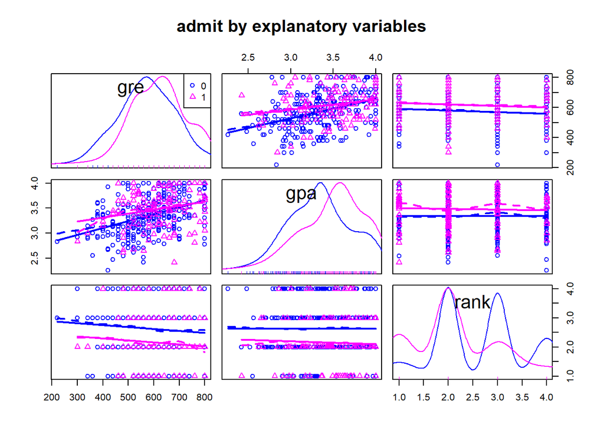

```r
scatterplotMatrix(~gre+gpa+rank|admit, data=admissions, legend = TRUE, regLine = TRUE,  main="admit by explanatory variables")
```

**Question 3.2:** Estimate a binary logistic regression using the following set of explanatory variables: $gre$, $gpa$, $rank$, $gre^2$, $gpa^2$, and $gre \times gpa$, where $gre \times gpa$ denotes the interaction between $gre$ and $gpa$ variables

```r
logit.model <- glm(admit ~ gre + gpa + rank + I(gre^2) + gre:gpa, data = admissions, family = binomial(link="logit"))
summary(logit.model)
```

```
##
## Call:
## glm(formula = admit ~ gre + gpa + rank + I(gre^2) + gre:gpa,
##     family = binomial(link = "logit"), data = admissions)
##
## Deviance Residuals:
##     Min       1Q   Median       3Q      Max
## -1.4721  -0.8754  -0.6346   1.1279   2.1981
##
## Coefficients:
##               Estimate Std. Error z value Pr(>|z|)
## (Intercept) -1.343e+01  6.044e+00  -2.223 0.026249 *
## gre          1.629e-02  1.157e-02   1.408 0.159023
## gpa          3.883e+00  1.907e+00   2.036 0.041768 *
## rank2       -7.168e-01  3.196e-01  -2.243 0.024895 *
## rank3       -1.341e+00  3.465e-01  -3.870 0.000109 ***
## rank4       -1.609e+00  4.213e-01  -3.819 0.000134 ***
## I(gre^2)     2.770e-06  8.184e-06   0.338 0.734994
## gre:gpa     -5.090e-03  3.088e-03  -1.649 0.099215 .
## ---
## Signif. codes:  0 '***' 0.001 '**' 0.01 '*' 0.05 '.' 0.1 ' ' 1
##
## (Dispersion parameter for binomial family taken to be 1)
##
##     Null deviance: 499.98  on 399  degrees of freedom
## Residual deviance: 455.66  on 392  degrees of freedom
## AIC: 471.66
##
## Number of Fisher Scoring iterations: 4
```

**Question 3.3:** Test the hypothesis that GRE has no effect on admission using the likelihood ratio test

```r
library(car)
Anova(logit.model, test="LR")
```

```
## Analysis of Deviance Table (Type II tests)
##
## Response: admit
##          LR Chisq Df Pr(>Chisq)
## gre        0.3394  1    0.56020
## gpa        5.8870  1    0.01525 *
## rank      22.1058  3  6.201e-05 ***
## I(gre^2)   0.1136  1    0.73611
## gre:gpa    2.7518  1    0.09715 .
## ---
## Signif. codes:  0 '***' 0.001 '**' 0.01 '*' 0.05 '.' 0.1 ' ' 1
```

**Question 3.4:** What is the estimated effect of college GPA on admission?